# SmithKaartOefening1 slides

Smith Kaart

Oefening 1

Jan Genoe

December 2025

###### Opgave Oefening 1

Pas aan de hand van een Smith kaart om een antenne van 128 Ohm aan aan een striplijn printbaan van 50 Ohm voor een frequentie van 1.2 GHz ($\lambda$= 12.5 cm; $\epsilon_{r}$=4). Doe dit door een condensator in parallel op de 50 Ohm lijn te plaatsen. Waar moet deze condensator staan en hoe groot moet deze zijn? Wanneer 250 mW naar deze antenne gestuurd wordt, hoe groot is dan de maximale spanning aan de voet van de antenne? Hoe groot is de maximale spanning op de plaats waar de condensator is aangesloten?

###### Smith kaart van de impedantie Z

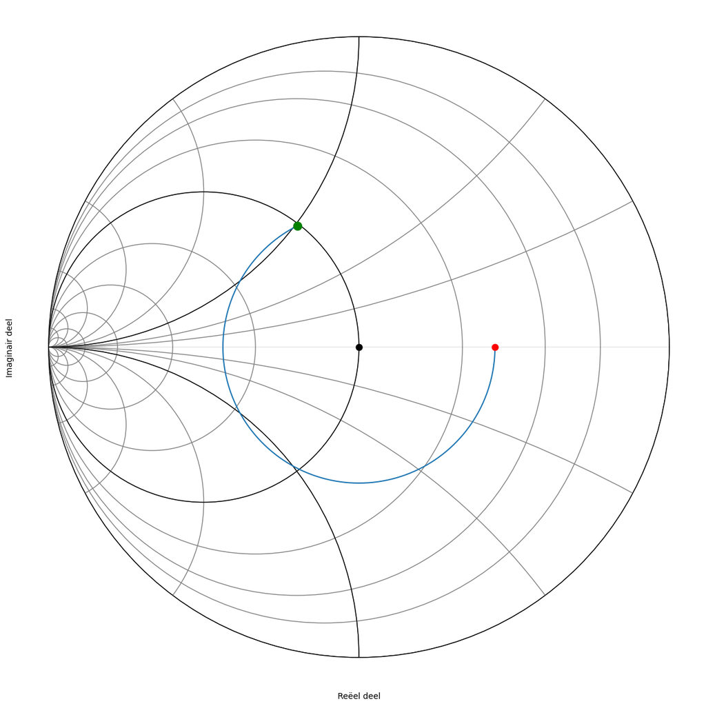

###### Smith kaart van de admittantie waarop de cirkels van constant reeel en imaginair van de admittantie aangegeven zijn.

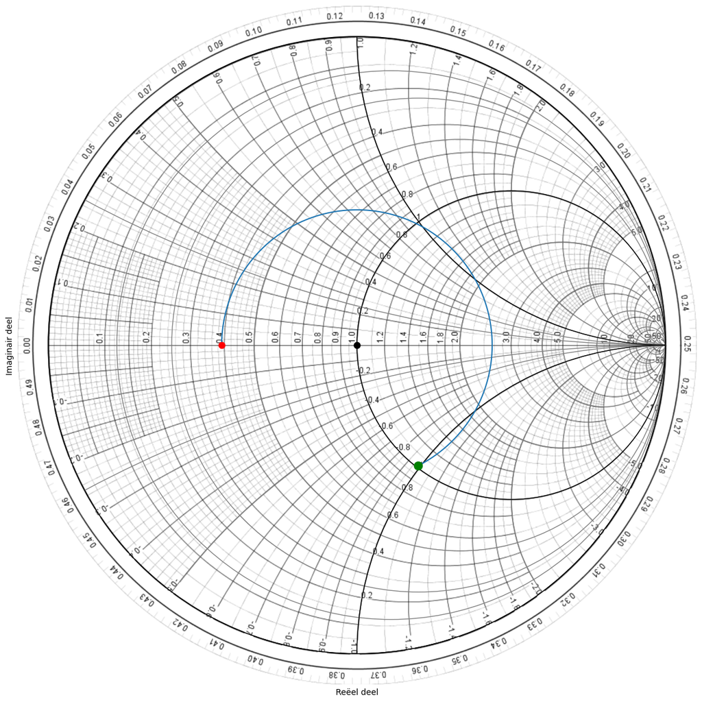

###### Smith kaart van de admittantie

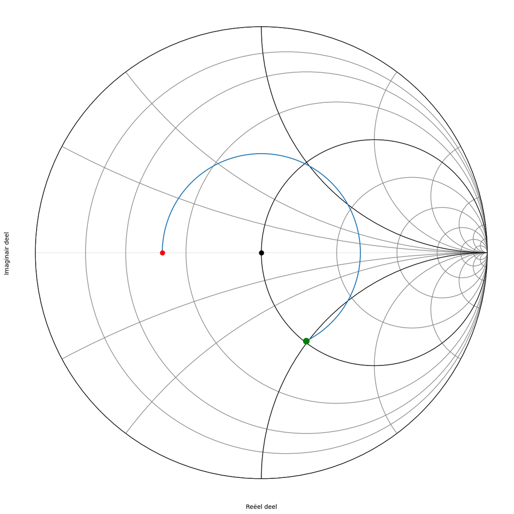

###### Gedetailleerde waarde van de admittantie

```
hoek    admittantie (Siemens)     lengte coax (cm)
 242    Y= 20.70-19.83j mS     lengte=4.20 cm
 243    Y= 20.35-19.67j mS     lengte=4.22 cm
 244    Y= 20.00-19.50j mS     lengte=4.24 cm
 245    Y= 19.67-19.33j mS     lengte=4.25 cm
 246    Y= 19.34-19.16j mS     lengte=4.27 cm
```

###### Condensator in parallel

De admittantie ter hoogte van waar we de condensator willen bijplaatsen is dus: 20.00-19.50j mS

Om op 20 mS uit te komen tellen we hierbij 19.50j mS op

De nodige condensator is dus:

$$ j \omega C= 0.0195 j $$

$$ C =\frac{0.0195}{2 \pi \cdot 1.2 \times 10^9}= 2.59 pF $$

###### Lengte coax

De lengte van de coax tussen de capaciteit en de belasting wordt:

$$\frac{244}{360}\frac{\lambda}{2}= \frac{244}{360}\frac{12.5}{2}= 4.24 cm$$

###### circuit van de gevraagde aanpassing

[figure not shown]

###### Gevraagde spanningen en stromen

[figure not shown]

I would rather have questions that can't be answered  
than answers that can't be questioned.

Richard Feynman